# Practical Machine Learning Project

Shahfik Amasha

15 October 2015

## Introduction

The goal of this project is to predict the manner in which 6 participants did their exercises. The participants were asked to perform barbell lifts correctly and incorrectly in 5 different ways.

- Class A: Exactly according to the specification, i.e. the correct way
- Class B: Throwing the elbows to the front
- Class C: Lifting the dumbbell only halfway
- Class D: Lowering the dumbbell only halfway, and
- Class E: Throwing the hips to the front

The following packages are used in this project. The random seed is also set to ensure reproduceability.

```r
library(caret)
```

```r
library(rpart)
library(rpart.plot)
library(randomForest)
library(rattle)
set.seed(123)
```

## Load & Transform

1. The datasets to be used for the project are loaded. The testing dataset contains the 20 problems to be submitted. The training dataset will be further partitioned into training and testing datasets (60% and 40% respectively) for modelling.

```r
training <- read.csv("pml-training.csv", na.strings=c("NA","#DIV/0!",""))
testing <- read.csv("pml-testing.csv", na.strings=c("NA","#DIV/0!",""))

inTrain <- createDataPartition(y=training$classe, p=0.6, list=FALSE)
myTraining <- training[inTrain, ]
myTesting <- training[-inTrain, ]
dim(myTraining); dim(myTesting)
```

```
## [1] 11776   160
```

```
## [1] 7846  160
```

2. The following three steps cleans the data to prepare for the model building. The myTraining dataset is used to determine the columns to be removed. The same columns will then be removed from the myTesting and testing
1. Columns which contians more than 90% NA are removed.

```r
naColumns <- sapply(myTraining, function(x) mean(is.na(x))) > 0.9
myTraining <- myTraining[, naColumns==F]
myTesting <- myTesting[, naColumns==F]
testing <- testing[, naColumns==F]
```

2. NearZeroVariance variables are removed.

```r
nzv <- nearZeroVar(myTraining)
myTraining <- myTraining[, -nzv]
myTesting <- myTesting[, -nzv]
testing <- testing[, -nzv]
```

3. The first five columns are removed as they are not used for building the model.

```r
myTraining <- myTraining[, -(1:5)]
myTesting <- myTesting[, -(1:5)]
testing <- testing[, -(1:5)]
dim(myTraining); dim(myTesting);dim(testing)
```

```
## [1] 11776    54
```

```
## [1] 7846   54
```

```
## [1] 20 54
```

## Modelling & Evaluation

Two modelling techniques will be used, (a) RandomForest, and (b) Decision Tree

**(a) RandomForest** The myTraining dataset is modelled using RandomForest with a 3-fold cross-validation.

```r
rfFitControl <- trainControl(method="cv", number=3, verboseIter=F)
rfFit <- train(classe ~ ., data=myTraining, method="rf", trControl=rfFitControl)
rfFit$finalModel
```

```
##
## Call:
##  randomForest(x = x, y = y, mtry = param$mtry)
##                Type of random forest: classification
##                      Number of trees: 500
## No. of variables tried at each split: 27
##
##         OOB estimate of  error rate: 0.33%
## Confusion matrix:
##      A    B    C    D    E  class.error
## A 3346    1    0    0    1 0.0005973716
## B    5 2271    2    1    0 0.0035103115
## C    0    6 2046    2    0 0.0038948393
## D    0    0   14 1915    1 0.0077720207
## E    0    1    0    5 2159 0.0027713626
```

The fitted model is then used to predict the column classe in myTesting. The results of the prediction is them compared against the actual values using a confusion matrix.

```r
rfPreds <- predict(rfFit, newdata=myTesting)
confusionMatrix(myTesting$classe, rfPreds)
```

```
## Confusion Matrix and Statistics
##
##           Reference
## Prediction    A    B    C    D    E
##          A 2232    0    0    0    0
##          B    1 1515    2    0    0
##          C    0    4 1362    2    0
##          D    0    0    7 1279    0
##          E    0    0    0    2 1440
##
## Overall Statistics
##
##                Accuracy : 0.9977
##                  95% CI : (0.9964, 0.9986)
##     No Information Rate : 0.2846
##     P-Value [Acc > NIR] : < 2.2e-16
##
##                   Kappa : 0.9971
##  Mcnemar's Test P-Value : NA
##
## Statistics by Class:
##
##                      Class: A Class: B Class: C Class: D Class: E
## Sensitivity            0.9996   0.9974   0.9934   0.9969   1.0000
## Specificity            1.0000   0.9995   0.9991   0.9989   0.9997
## Pos Pred Value         1.0000   0.9980   0.9956   0.9946   0.9986
## Neg Pred Value         0.9998   0.9994   0.9986   0.9994   1.0000
## Prevalence             0.2846   0.1936   0.1747   0.1635   0.1835
## Detection Rate         0.2845   0.1931   0.1736   0.1630   0.1835
## Detection Prevalence   0.2845   0.1935   0.1744   0.1639   0.1838
## Balanced Accuracy      0.9998   0.9984   0.9963   0.9979   0.9998
```

**(b) Decision Tree** The myTraining dataset is modelled using a decision tree.

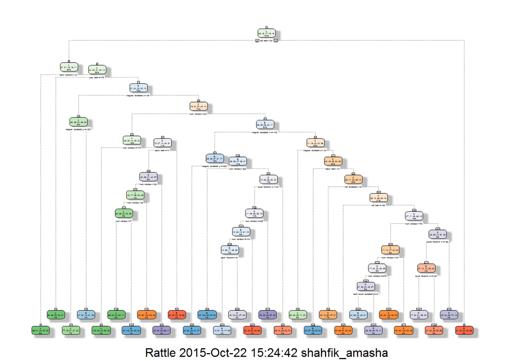

```r
dtFit <- rpart(classe ~ ., data=myTraining, method="class")
fancyRpartPlot(dtFit)
```

Similarly, the fitted model is then used to predict the column classe in myTesting. The results of the prediction is them compared against the actual values using a confusion matrix.

```r
dtPreds <- predict(dtFit, myTesting, type = "class")
confusionMatrix(dtPreds, myTesting$classe)
```

```
## Confusion Matrix and Statistics
##
##           Reference
## Prediction    A    B    C    D    E
##          A 2031  243   43   62   36
##          B   90 1044  135  110   62
##          C    0   76 1043   42    5
##          D   86   60  129  993  121
##          E   25   95   18   79 1218
##
## Overall Statistics
##
##                Accuracy : 0.8067
##                  95% CI : (0.7977, 0.8153)
##     No Information Rate : 0.2845
##     P-Value [Acc > NIR] : < 2.2e-16
##
##                   Kappa : 0.7547
##  Mcnemar's Test P-Value : < 2.2e-16
##
## Statistics by Class:
##
##                      Class: A Class: B Class: C Class: D Class: E
## Sensitivity            0.9099   0.6877   0.7624   0.7722   0.8447
## Specificity            0.9316   0.9373   0.9810   0.9396   0.9661
## Pos Pred Value         0.8410   0.7245   0.8945   0.7149   0.8488
## Neg Pred Value         0.9630   0.9260   0.9513   0.9546   0.9651
## Prevalence             0.2845   0.1935   0.1744   0.1639   0.1838
## Detection Rate         0.2589   0.1331   0.1329   0.1266   0.1552
## Detection Prevalence   0.3078   0.1837   0.1486   0.1770   0.1829
## Balanced Accuracy      0.9208   0.8125   0.8717   0.8559   0.9054
```

**Conclusion** Using RandomForest yielded a better prediction than Decision Tree.

## Generating Project Submission Files

The RandomForest model is used on the 20 problems in the Testing dataset. A file is generated for each problem for submission.

```r
classPreds <- predict(rfFit, newdata=testing)
classPreds <- as.character(classPreds)

pml_write_files <- function(x) {
    n <- length(x)
    for(i in 1:n) {
        filename <- paste0("problem_id_", i, ".txt")
        write.table(x[i], file=filename, quote=F, row.names=F, col.names=F)
    }
}

pml_write_files(classPreds)
```

## Reference

Velloso, E.; Bulling, A.; Gellersen, H.; Ugulino, W.; Fuks, H. Qualitative Activity Recognition of Weight Lifting Exercises. Proceedings of 4th International Conference in Cooperation with SIGCHI (Augmented Human ’13) . Stuttgart, Germany: ACM SIGCHI, 2013